# **Lab 8**

```python
%matplotlib inline
import numpy as np
import matplotlib
import matplotlib.pyplot as plt
import scipy
import statistics
import math
from scipy import stats
import h5py
import pandas as pd
import pickle
```

**Set Up**

In this lab, we will perform pseudo-experiment data analysis. We will be using our optimized event selection to hunt for our signal by using one of the pseudo-experiment dataset. For each problem, we will choose one of the observed data from our specific pT sample to perform the analysis.

```python
# higgs data
higgs_file = open("higgs_100000_pt_250_500.pkl",'rb')
higgs_dict = pickle.load(higgs_file)
higgs_data = pd.DataFrame(higgs_dict)
print("Higgs Data:", higgs_data.keys())
```

```
Higgs Data: Index(['pt', 'eta', 'phi', 'mass', 'ee2', 'ee3', 'd2', 'angularity', 't1',
       't2', 't3', 't21', 't32', 'KtDeltaR'],
      dtype='object')
```

```python
# qcd data
qcd_file = open("qcd_100000_pt_250_500.pkl",'rb')
qcd_dict = pickle.load(qcd_file)
qcd_data = pd.DataFrame(qcd_dict)
print("QCD Data:", qcd_data.keys())
```

```
QCD Data: Index(['pt', 'eta', 'phi', 'mass', 'ee2', 'ee3', 'd2', 'angularity', 't1',
       't2', 't3', 't21', 't32', 'KtDeltaR'],
      dtype='object')
```

```python
# high luminosity
high_lumi = pd.read_hdf('data_highLumi_pt_250_500.h5')
print("High Lumi:", high_lumi.keys())
```

```
High Lumi: Index(['pt', 'eta', 'phi', 'mass', 'ee2', 'ee3', 'd2', 'angularity', 't1',
       't2', 't3', 't21', 't32', 'KtDeltaR'],
      dtype='object')
```

```python
# low luminosity
low_lumi = pd.read_hdf('data_lowLumi_pt_250_500.h5')
print("Low Lumi:", low_lumi.keys())
```

```
Low Lumi: Index(['pt', 'eta', 'phi', 'mass', 'ee2', 'ee3', 'd2', 'angularity', 't1',
       't2', 't3', 't21', 't32', 'KtDeltaR'],
      dtype='object')
```

```python
# returns an arr with values greater than a and b and its significance
def cut(a,b,higgs,qcd):
    # filter out values outside of a and b
    higgs_cut = higgs[higgs>a]
    higgs_cut = higgs_cut[higgs_cut<b]

    qcd_cut = qcd[qcd>a]
    qcd_cut = qcd_cut[qcd_cut<b]

    # gets cut version of array and significance
    higgs_n = 100*len(higgs_cut)/len(higgs)
    qcd_n = 20000*len(qcd_cut)/len(qcd)

    sig = abs(stats.norm.ppf(1-stats.poisson.cdf(higgs_n+qcd_n,qcd_n)))
    print(f"Significance for Range {a}-{b}:", sig)
    return higgs_cut, qcd_cut, sig
```

```python
# returns arr with optimal mass cut
def opt_cut(higgs,qcd):
    # filter out values outside of optimal mass cut
    higgs_cut = higgs[higgs_data.mass>124]
    higgs_cut = higgs_cut[higgs_data.mass<128]

    qcd_cut = qcd[qcd_data.mass>124]
    qcd_cut = qcd_cut[qcd_data.mass<128]

    return higgs_cut, qcd_cut
```

```python
# feature cuts with optimal mass cut in range 124 to 128
mcut_pt = opt_cut(higgs_data.pt,qcd_data.pt)
mcut_eta = opt_cut(higgs_data.eta,qcd_data.eta)
mcut_phi = opt_cut(higgs_data.phi,qcd_data.phi)
mcut_ee2 = opt_cut(higgs_data.ee2,qcd_data.ee2)
mcut_ee3 = opt_cut(higgs_data.ee3,qcd_data.ee3)
mcut_d2 = opt_cut(higgs_data.d2,qcd_data.d2)
mcut_angularity = opt_cut(higgs_data.angularity,qcd_data.angularity)
mcut_t1 = opt_cut(higgs_data.t1,qcd_data.t1)
mcut_t2 = opt_cut(higgs_data.t2,qcd_data.t2)
mcut_t3 = opt_cut(higgs_data.t3,qcd_data.t3)
mcut_t21 = opt_cut(higgs_data.t21,qcd_data.t21)
mcut_t32 = opt_cut(higgs_data.t32,qcd_data.t32)
mcut_KtDeltaR = opt_cut(higgs_data.KtDeltaR,qcd_data.KtDeltaR)
```

```python
# feature cuts with best significance with optimal mass cut
opt_pt = cut(473,487,mcut_pt[0],mcut_pt[1])
opt_eta = cut(-1.7,1.7,mcut_eta[0],mcut_eta[1])
opt_phi = cut(-3,3,mcut_phi[0],mcut_phi[1])
opt_mass = cut(124,128,higgs_data.mass,qcd_data.mass)
opt_ee2 = cut(0,0.22,mcut_ee2[0],mcut_ee2[1])
opt_ee3 = cut(0,0.05,mcut_ee3[0],mcut_ee3[1])
opt_d2 = cut(0,0.8,mcut_d2[0],mcut_d2[1])
opt_angularity = cut(0,0.01,mcut_angularity[0],mcut_angularity[1])
opt_t1 = cut(0,2,mcut_t1[0],mcut_t1[1])
opt_t2 = cut(0,0.2,mcut_t2[0],mcut_t2[1])
opt_t3 = cut(0,0.14,mcut_t3[0],mcut_t3[1])
opt_t21 = cut(0,0.18,mcut_t21[0],mcut_t21[1])
opt_t32 = cut(0.25,1,mcut_t32[0],mcut_t32[1])
opt_KtDeltaR = cut(0.44,0.76,mcut_KtDeltaR[0],mcut_KtDeltaR[1])
```

```
Significance for Range 473-487: 0.7702728237489497
Significance for Range -1.7-1.7: 0.7371100423821891
Significance for Range -3-3: 0.6955498072712277
Significance for Range 124-128: 3.0337389952368543
Significance for Range 0-0.22: 0.6956980921186786
Significance for Range 0-0.05: 0.7112259282313185
Significance for Range 0-0.8: 4.405256799282586
Significance for Range 0-0.01: 0.7715155819683535
Significance for Range 0-2: 0.7071765170700753
Significance for Range 0-0.2: 2.203048176213319
Significance for Range 0-0.14: 2.500134813493844
Significance for Range 0-0.18: 2.1939338779686968
Significance for Range 0.25-1: 0.7075230733000805
Significance for Range 0.44-0.76: 0.9597062608756513
```

**Problem 1**

Here, we will be focusing on the high luminosity data.

**Section 1a**

Here, we will focus on each feature of our event selection. Specifically, we will plot the observed high luminosity data overlapped with expected signal and background without event selection.

```python
# feature cuts with best significance with optimal mass cut
hl_pt = cut(473,487,high_lumi.pt,high_lumi.pt)
hl_eta = cut(-1.7,1.7,high_lumi.eta,high_lumi.eta)
hl_phi = cut(-3,3,high_lumi.phi,high_lumi.eta)
hl_mass = cut(124,128,high_lumi.mass,high_lumi.mass)
hl_ee2 = cut(0,0.22,high_lumi.ee2,high_lumi.ee2)
hl_ee3 = cut(0,0.05,high_lumi.ee3,high_lumi.ee3)
hl_d2 = cut(0,0.8,high_lumi.d2,high_lumi.d2)
hl_angularity = cut(0,0.01,high_lumi.angularity,high_lumi.angularity)
hl_t1 = cut(0,2,high_lumi.t1,high_lumi.t1)
hl_t2 = cut(0,0.2,high_lumi.t2,high_lumi.t2)
hl_t3 = cut(0,0.14,high_lumi.t3,high_lumi.t3)
hl_t21 = cut(0,0.18,high_lumi.t21,high_lumi.t21)
hl_t32 = cut(0.25,1,high_lumi.t32,high_lumi.t32)
hl_KtDeltaR = cut(0.44,0.76,high_lumi.KtDeltaR,high_lumi.KtDeltaR)
```

```
Significance for Range 473-487: 0.26365244406559724
Significance for Range -1.7-1.7: 0.6413323102338069
Significance for Range -3-3: 0.6754499404689157
Significance for Range 124-128: 0.09760208761630187
Significance for Range 0-0.22: 0.6898499705159629
Significance for Range 0-0.05: 0.7097768202101543
Significance for Range 0-0.8: 0.08482896491973127
Significance for Range 0-0.01: 0.6509838547731975
Significance for Range 0-2: 0.7065646768564796
Significance for Range 0-0.2: 0.13027711374270598
Significance for Range 0-0.14: 0.09723203259475685
Significance for Range 0-0.18: 0.08702122955559798
Significance for Range 0.25-1: 0.7110555456221102
Significance for Range 0.44-0.76: 0.3284803110236002
```

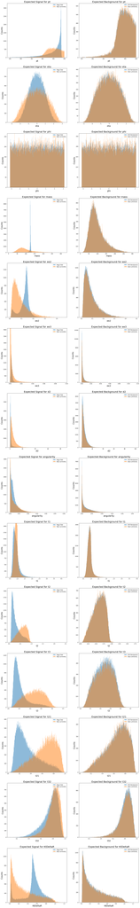

```python
fig, ax = plt.subplots(14, 2)
fig.set_size_inches(20,140)
features = ['pt','eta','phi','mass','ee2','ee3','d2', \
            'angularity','t1','t2','t3','t21','t32','KtDeltaR']

for i in range(14):
    feature = features[i]
    ax[i,0].set_title(f"Expected Signal for {feature}", fontsize=20)
    ax[i,0].set_xlabel(feature, fontsize=18)
    ax[i,0].set_ylabel('Counts', fontsize=18)
    ax[i,0].hist(higgs_data[feature],500,alpha=0.5,label='Higgs Data')
    n, bins, rects = ax[i,0].hist(high_lumi[feature],500,alpha=0.5,label='High Luminosity')
    for r in rects:
        factor = len(high_lumi[feature])/len(higgs_data[feature])
        r.set_height(r.get_height()/factor)
    ax[i,0].legend(loc='upper right')

    ax[i,1].set_title(f"Expected Background for {feature}", fontsize=20)
    ax[i,1].set_xlabel(feature, fontsize=18)
    ax[i,1].set_ylabel('Counts', fontsize=18)
    ax[i,1].hist(qcd_data[feature],500,alpha=0.5,label='QCD Background')
    n, bins, rects = ax[i,1].hist(high_lumi[feature],500,alpha=0.5,label='High Luminosity')
    for r in rects:
        factor = len(high_lumi[feature])/len(qcd_data[feature])
        r.set_height(r.get_height()/factor)
    ax[i,1].legend(loc='upper right')
```

**Section 1b**

Here, we will plot observed data with overlap with expected signal and background (normalized to observed yields) with optimal event selection.

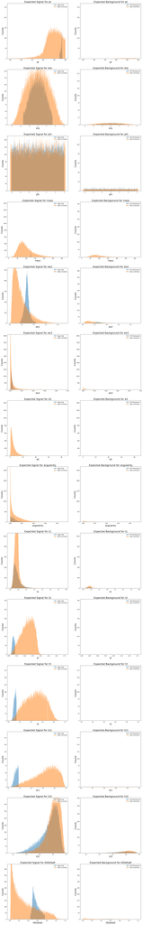

```python
fig, ax = plt.subplots(14, 2)
fig.set_size_inches(20,140)
features = ['pt','eta','phi','mass','ee2','ee3','d2', \
            'angularity','t1','t2','t3','t21','t32','KtDeltaR']
data = [opt_pt,opt_eta,opt_phi,opt_mass,opt_ee2,opt_ee3,opt_d2, \
        opt_angularity,opt_t1,opt_t2,opt_t3,opt_t21,opt_t32,opt_KtDeltaR]

for i in range(14):
    feature = features[i]
    ax[i,0].set_title(f"Expected Signal for {feature}", fontsize=20)
    ax[i,0].set_xlabel(feature, fontsize=18)
    ax[i,0].set_ylabel('Counts', fontsize=18)
    ax[i,0].hist(data[i][0],500,alpha=0.5,label='Higgs Data')
    n, bins, rects = ax[i,0].hist(high_lumi[feature],500,alpha=0.5,label='High Luminosity')
    for r in rects:
        factor = len(high_lumi[feature])/len(data[i][0])
        r.set_height(r.get_height()/factor)
    ax[i,0].legend(loc='upper right')

    ax[i,1].set_title(f"Expected Background for {feature}", fontsize=20)
    ax[i,1].set_xlabel(feature, fontsize=18)
    ax[i,1].set_ylabel('Counts', fontsize=18)
    ax[i,1].hist(data[i][1],500,alpha=0.5,label='QCD Background')
    n, bins, rects = ax[i,1].hist(high_lumi[feature],500,alpha=0.5,label='High Luminosity')
    for r in rects:
        factor = len(high_lumi[feature])/len(data[i][1])
        r.set_height(r.get_height()/factor)
    ax[i,1].legend(loc='upper right')
```

**Section 1c**

Here, we will evaluate observed significance and compare our results to expectation. Here, we see the significance of the observed data and the expected data are very different. For a majority of the features, we have a significance of infinity in the observed data. The features with a non-infinity value, only the t3 feature is somewhat similar to the expected. This is most likely because of the length of the cut background data being too small which could affect the significance.

```python
print(high_lumi.shape)
```

```
(40344, 14)
```

```python
features = ['pt','eta','phi','mass','ee2','ee3','d2', \
            'angularity','t1','t2','t3','t21','t32','KtDeltaR']
hl_data = [hl_pt,hl_eta,hl_phi,hl_mass,hl_ee2,hl_ee3,hl_d2, \
        hl_angularity,hl_t1,hl_t2,hl_t3,hl_t21,hl_t32,hl_KtDeltaR]
opt_data = [opt_pt,opt_eta,opt_phi,opt_mass,opt_ee2,opt_ee3,opt_d2, \
        opt_angularity,opt_t1,opt_t2,opt_t3,opt_t21,opt_t32,opt_KtDeltaR]

for i in range(14):
    feature = features[i]
    signal_mean = 40344*len(hl_data[i])/len(high_lumi)
    bkgd_mean = 40344*len(opt_data[i][1])/len(qcd_data[feature])
    p = abs(stats.norm.ppf(1-stats.poisson.cdf(signal_mean,bkgd_mean)))
    print(f'Sigma for {feature}:', p)
```

```
Sigma for pt: inf
Sigma for eta: inf
Sigma for phi: inf
Sigma for mass: inf
Sigma for ee2: inf
Sigma for ee3: inf
Sigma for d2: 0.753408856208908
Sigma for angularity: inf
Sigma for t1: inf
Sigma for t2: 4.470240213576786
Sigma for t3: 2.3375793117552672
Sigma for t21: 1.344164290790846
Sigma for t32: inf
Sigma for KtDeltaR: inf
```

```python
for i in range(14):
    feature = features[i]
    print(f'Sigma for {feature}:', opt_data[i][2])
```

```
Sigma for pt: 0.7702728237489497
Sigma for eta: 0.7371100423821891
Sigma for phi: 0.6955498072712277
Sigma for mass: 3.0337389952368543
Sigma for ee2: 0.6956980921186786
Sigma for ee3: 0.7112259282313185
Sigma for d2: 4.405256799282586
Sigma for angularity: 0.7715155819683535
Sigma for t1: 0.7071765170700753
Sigma for t2: 2.203048176213319
Sigma for t3: 2.500134813493844
Sigma for t21: 2.1939338779686968
Sigma for t32: 0.7075230733000805
Sigma for KtDeltaR: 0.9597062608756513
```

**Problem 2**

Here, we will be focusing on the low luminosity data.

**Section 2a**

Here, we will focus on each feature of our event selection. Specifically, we will plot observed data with overlap with expected signal and background without event selection.

```python
# feature cuts with best significance with optimal mass cut
ll_pt = cut(473,487,low_lumi.pt,low_lumi.pt)
ll_eta = cut(-1.7,1.7,low_lumi.eta,low_lumi.eta)
ll_phi = cut(-3,3,low_lumi.phi,low_lumi.eta)
ll_mass = cut(124,128,low_lumi.mass,low_lumi.mass)
ll_ee2 = cut(0,0.22,low_lumi.ee2,low_lumi.ee2)
ll_ee3 = cut(0,0.05,low_lumi.ee3,low_lumi.ee3)
ll_d2 = cut(0,0.8,low_lumi.d2,low_lumi.d2)
ll_angularity = cut(0,0.01,low_lumi.angularity,low_lumi.angularity)
ll_t1 = cut(0,2,low_lumi.t1,low_lumi.t1)
ll_t2 = cut(0,0.2,low_lumi.t2,low_lumi.t2)
ll_t3 = cut(0,0.14,low_lumi.t3,low_lumi.t3)
ll_t21 = cut(0,0.18,low_lumi.t21,low_lumi.t21)
ll_t32 = cut(0.25,1,low_lumi.t32,low_lumi.t32)
ll_KtDeltaR = cut(0.44,0.76,low_lumi.KtDeltaR,low_lumi.KtDeltaR)
```

```
Significance for Range 473-487: 0.24966821724221971
Significance for Range -1.7-1.7: 0.6406830916088556
Significance for Range -3-3: 0.6750509076867067
Significance for Range 124-128: 0.12953544596064534
Significance for Range 0-0.22: 0.6921220169449986
Significance for Range 0-0.05: 0.7060088536810489
Significance for Range 0-0.8: 0.09047235123134495
Significance for Range 0-0.01: 0.6486883808830344
Significance for Range 0-2: 0.7086191323874865
Significance for Range 0-0.2: 0.10381400156762524
Significance for Range 0-0.14: 0.11170667160384043
Significance for Range 0-0.18: 0.11199408641387468
Significance for Range 0.25-1: 0.7107917036479113
Significance for Range 0.44-0.76: 0.32164866801375885
```

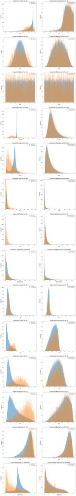

```python
fig, ax = plt.subplots(14, 2)
fig.set_size_inches(20,140)
features = ['pt','eta','phi','mass','ee2','ee3','d2', \
            'angularity','t1','t2','t3','t21','t32','KtDeltaR']

for i in range(14):
    feature = features[i]
    ax[i,0].set_title(f"Expected Signal for {feature}", fontsize=20)
    ax[i,0].set_xlabel(feature, fontsize=18)
    ax[i,0].set_ylabel('Counts', fontsize=18)
    ax[i,0].hist(higgs_data[feature],500,alpha=0.5,label='Higgs Data')
    n, bins, rects = ax[i,0].hist(low_lumi[feature],500,alpha=0.5,label='Low Luminosity')
    for r in rects:
        factor = len(low_lumi[feature])/len(higgs_data[feature])
        r.set_height(r.get_height()/factor)
    ax[i,0].legend(loc='upper right')

    ax[i,1].set_title(f"Expected Background for {feature}", fontsize=20)
    ax[i,1].set_xlabel(feature, fontsize=18)
    ax[i,1].set_ylabel('Counts', fontsize=18)
    ax[i,1].hist(qcd_data[feature],500,alpha=0.5,label='QCD Background')
    n, bins, rects = ax[i,1].hist(low_lumi[feature],500,alpha=0.5,label='Low Luminosity')
    for r in rects:
        factor = len(low_lumi[feature])/len(qcd_data[feature])
        r.set_height(r.get_height()/factor)
    ax[i,1].legend(loc='upper right')
```

**Section 2b**

Here, we will plot observed data with overlap with expected signal and background (normalized to observed yields) with optimal event selection.

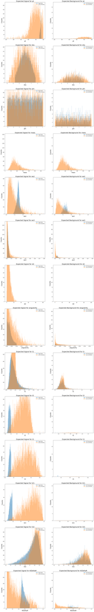

```python
fig, ax = plt.subplots(14, 2)
fig.set_size_inches(20,140)
features = ['pt','eta','phi','mass','ee2','ee3','d2', \
            'angularity','t1','t2','t3','t21','t32','KtDeltaR']
data = [opt_pt,opt_eta,opt_phi,opt_mass,opt_ee2,opt_ee3,opt_d2, \
        opt_angularity,opt_t1,opt_t2,opt_t3,opt_t21,opt_t32,opt_KtDeltaR]

for i in range(14):
    feature = features[i]
    ax[i,0].set_title(f"Expected Signal for {feature}", fontsize=20)
    ax[i,0].set_xlabel(feature, fontsize=18)
    ax[i,0].set_ylabel('Counts', fontsize=18)
    ax[i,0].hist(data[i][0],500,alpha=0.5,label='Higgs Data')
    n, bins, rects = ax[i,0].hist(low_lumi[feature],500,alpha=0.5,label='Low Luminosity')
    for r in rects:
        factor = len(low_lumi[feature])/len(data[i][0])
        r.set_height(r.get_height()/factor)
    ax[i,0].legend(loc='upper right')

    ax[i,1].set_title(f"Expected Background for {feature}", fontsize=20)
    ax[i,1].set_xlabel(feature, fontsize=18)
    ax[i,1].set_ylabel('Counts', fontsize=18)
    ax[i,1].hist(data[i][1],500,alpha=0.5,label='QCD Background')
    n, bins, rects = ax[i,1].hist(low_lumi[feature],500,alpha=0.5,label='Low Luminosity')
    for r in rects:
        factor = len(low_lumi[feature])/len(data[i][1])
        r.set_height(r.get_height()/factor)
    ax[i,1].legend(loc='upper right')
```

**Section 2c**

```python
print(low_lumi.shape)
```

```
(4060, 14)
```

```python
features = ['pt','eta','phi','mass','ee2','ee3','d2', \
            'angularity','t1','t2','t3','t21','t32','KtDeltaR']
ll_data = [ll_pt,ll_eta,ll_phi,ll_mass,ll_ee2,ll_ee3,ll_d2, \
        ll_angularity,ll_t1,ll_t2,ll_t3,ll_t21,ll_t32,ll_KtDeltaR]
opt_data = [opt_pt,opt_eta,opt_phi,opt_mass,opt_ee2,opt_ee3,opt_d2, \
        opt_angularity,opt_t1,opt_t2,opt_t3,opt_t21,opt_t32,opt_KtDeltaR]

for i in range(14):
    feature = features[i]
    bkgd_mean = 4060*len(data[i][1])/len(qcd_data[feature])
    signal_mean = 4060*len(ll_data[i])/len(low_lumi)
    p = abs(stats.norm.ppf(1-stats.poisson.cdf(signal_mean,bkgd_mean)))
    print(f'Sigma for {feature}:', p)
```

```
Sigma for pt: 2.7176812484694897
Sigma for eta: inf
Sigma for phi: inf
Sigma for mass: inf
Sigma for ee2: inf
Sigma for ee3: inf
Sigma for d2: 3.670918746252867
Sigma for angularity: inf
Sigma for t1: inf
Sigma for t2: 1.0759764810390513
Sigma for t3: 2.0553690777169273
Sigma for t21: 2.543989934037346
Sigma for t32: inf
Sigma for KtDeltaR: 6.248586007106633
```

```python
for i in range(14):
    feature = features[i]
    print(f'Sigma for {feature}:', opt_data[i][2])
```

```
Sigma for pt: 0.7702728237489497
Sigma for eta: 0.7371100423821891
Sigma for phi: 0.6955498072712277
Sigma for mass: 3.0337389952368543
Sigma for ee2: 0.6956980921186786
Sigma for ee3: 0.7112259282313185
Sigma for d2: 4.405256799282586
Sigma for angularity: 0.7715155819683535
Sigma for t1: 0.7071765170700753
Sigma for t2: 2.203048176213319
Sigma for t3: 2.500134813493844
Sigma for t21: 2.1939338779686968
Sigma for t32: 0.7075230733000805
Sigma for KtDeltaR: 0.9597062608756513
```

**Problem 3**

Here, we will be focusing on the 95% confidence level of signal yields.

**Section 3a**

```python
print(f'95% Confidence Level Upper Limit for Higgs Data:',np.percentile(higgs_data[:], 95))
print(f'95% Confidence Level Upper Limit for QCD Data:',np.percentile(qcd_data[:], 95))
print(f'95% Confidence Level Upper Limit for Low Luminosity Data:',np.percentile(low_lumi[:], 95))
```

```
95% Confidence Level Upper Limit for Higgs Data: 440.11661977740147
95% Confidence Level Upper Limit for QCD Data: 430.2609424749775
95% Confidence Level Upper Limit for Low Luminosity Data: 431.0428111501751
```

**Section 3b**

Here, we will evaluate the expected 95% confidence level upper limit.

```python
features = ['pt','eta','phi','mass','ee2','ee3','d2', \
            'angularity','t1','t2','t3','t21','t32','KtDeltaR']

for i in range(14):
    feature = features[i]
    print(f'95% Confidence Level Upper Limit for {feature}:', np.percentile(higgs_data[feature][:], 95))
```

```
95% Confidence Level Upper Limit for pt: 484.9859348850308
95% Confidence Level Upper Limit for eta: 1.468738124311948
95% Confidence Level Upper Limit for phi: 2.826618597115421
95% Confidence Level Upper Limit for mass: 128.97399684144975
95% Confidence Level Upper Limit for ee2: 0.18175287615104638
95% Confidence Level Upper Limit for ee3: 0.005970475731153569
95% Confidence Level Upper Limit for d2: 7.514395336130525
95% Confidence Level Upper Limit for angularity: 0.013443606449621956
95% Confidence Level Upper Limit for t1: 1.3031779304009063
95% Confidence Level Upper Limit for t2: 0.7286625184323081
95% Confidence Level Upper Limit for t3: 0.563534949937829
95% Confidence Level Upper Limit for t21: 0.7616336159111914
95% Confidence Level Upper Limit for t32: 0.913913837844326
95% Confidence Level Upper Limit for KtDeltaR: 0.8504034318430522
```

**Section 3c**

Here, we will evaluate the observed 95% confidence level upper limit.

```python
features = ['pt','eta','phi','mass','ee2','ee3','d2', \
            'angularity','t1','t2','t3','t21','t32','KtDeltaR']

for i in range(14):
    feature = features[i]
    print(f'95% Confidence Level Upper Limit for {feature}:', np.percentile(low_lumi[feature][:], 95))
```

```
95% Confidence Level Upper Limit for pt: 493.70999487244734
95% Confidence Level Upper Limit for eta: 1.9654106631514152
95% Confidence Level Upper Limit for phi: 2.8574566318968757
95% Confidence Level Upper Limit for mass: 182.21477345706785
95% Confidence Level Upper Limit for ee2: 0.22137822481218775
95% Confidence Level Upper Limit for ee3: 0.014120432452950402
95% Confidence Level Upper Limit for d2: 14.055036819777047
95% Confidence Level Upper Limit for angularity: 0.016257390247899937
95% Confidence Level Upper Limit for t1: 1.183658575946918
95% Confidence Level Upper Limit for t2: 0.8725844860774192
95% Confidence Level Upper Limit for t3: 0.7484979344864124
95% Confidence Level Upper Limit for t21: 0.9179045302438356
95% Confidence Level Upper Limit for t32: 0.9338485877932498
95% Confidence Level Upper Limit for KtDeltaR: 0.8396284507890209
```

**Section 3d**